# PD7

Karol Saputa

12 - 06 - 2019

# 1 Zastosowanie algorytmów klasteryzacji

Praca ma na celu przedstawienie przykładowych wyników klasteryzacji dla dwóch algorytmów:

- k-means
- k-medoids

## 1.1 Zbiór danych

“Image Segmentation Data Set The instances were drawn randomly from a database of 7 outdoor images. The images were hand-segmented to create a classification for every pixel. Each instance is a 3x3 region.” [1]

- 18 zmiennych numerycznych
- 2310 obserwacji

## 1.2 Wczytanie danych

## 1.3 Porównanie optymalnej liczby klastrów

### 1.3.1 SILHOUETTE (average silhouette width)

```r
print("kmeans")
```

```
## [1] "kmeans"
```

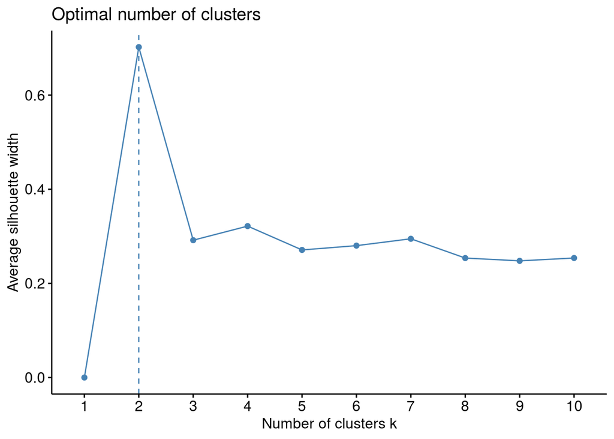

```r
fviz_nbclust(df, kmeans, method = "silhouette")
```

```r
print("k-medoids")
```

```
## [1] "k-medoids"
```

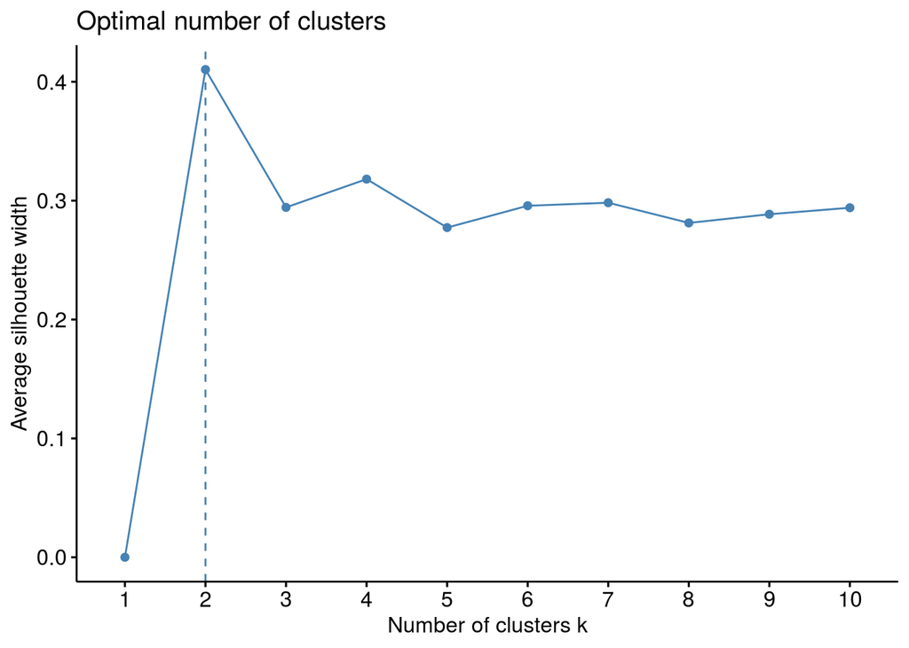

```r
fviz_nbclust(df, pam, method = "silhouette")
```

### 1.3.2 WSS (total within sum of square)

```r
print("kmeans")
```

```
## [1] "kmeans"
```

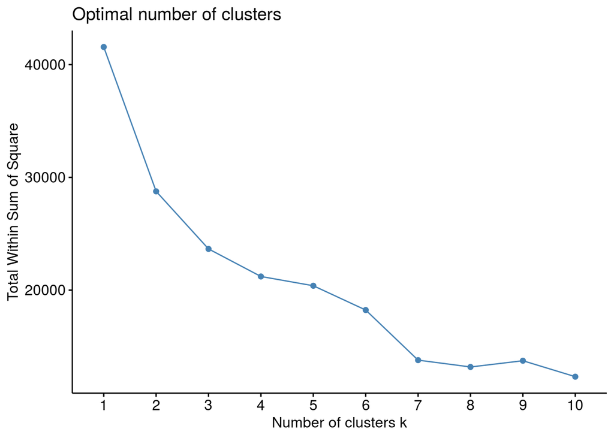

```r
fviz_nbclust(df, kmeans, method = "wss")
```

```r
print("k-medoids")
```

```
## [1] "k-medoids"
```

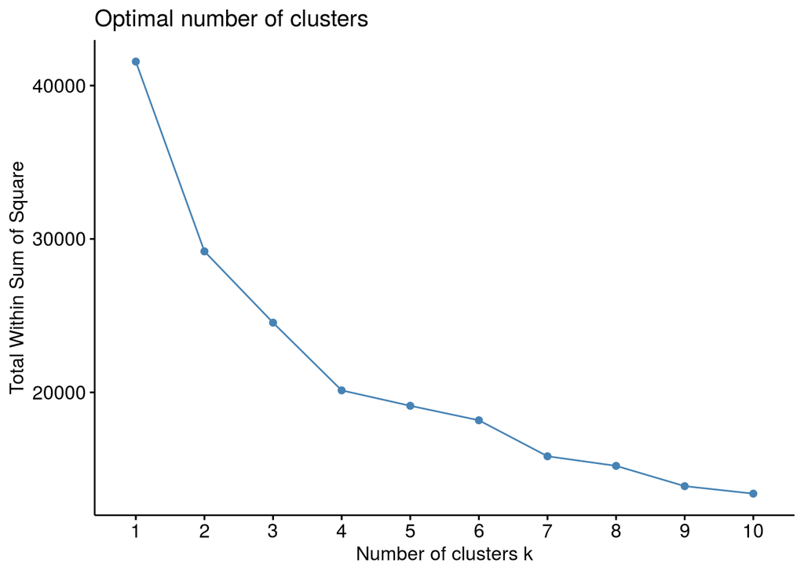

```r
fviz_nbclust(df, pam, method = "wss")
```

### 1.3.3 Analiza wyników

Na podstawie wykresów `silhouette` otrzymujemy optymalną liczbę klastrów równą 2. Natomiast dla metryki `wss` w przypadku w przypadku metody k-medoids trudno wyróżnić optymalną liczbę klastrów, jednak w przypadku k-means widać wyraźnie zmianę tendencji na wykresie dla siedmiu klastrów. Jest to o tyle ważne, że w oryginalnych danych właśnie taką liczbą unikalnych etykiet opatrzone są dane.

## 1.4 Porównanie klastrów

### 1.4.1 2 klastry

#### 1.4.1.1 k-means

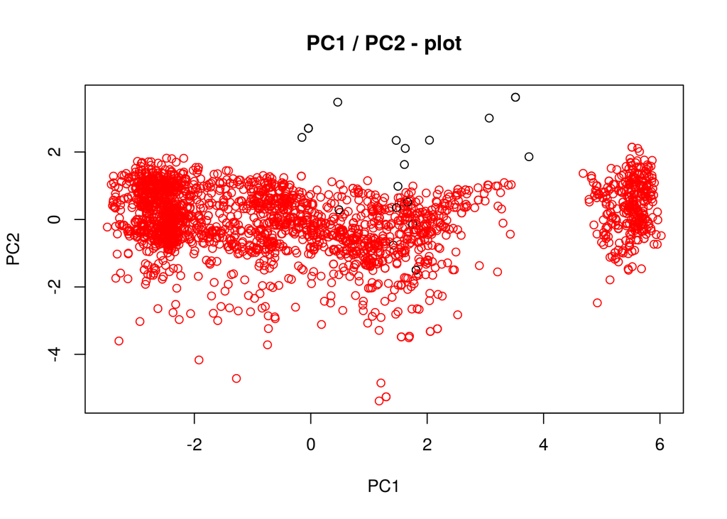

```r
clusters <- kmeans(df, 2)
pca_df <- prcomp(df)

plot(pca_df$x[,1], pca_df$x[,5], xlab="PC1", ylab = "PC2", main = "PC1 / PC2 - plot", col = clusters$cluster)
```

#### 1.4.1.2 k-medoids

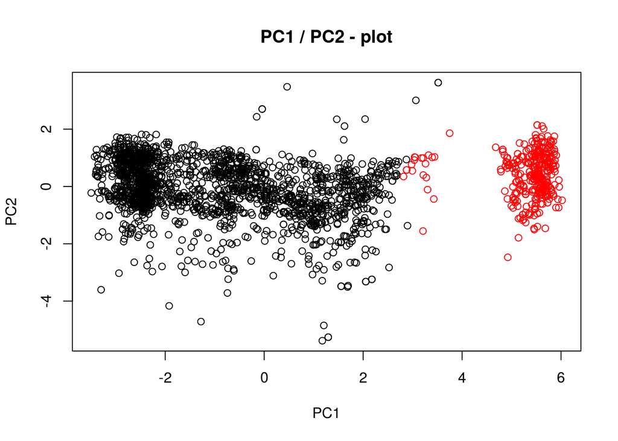

```r
clusters <- pam(df, 2)
pca_df <- prcomp(df)
plot(pca_df$x[,1], pca_df$x[,5], xlab="PC1", ylab = "PC2", main = "PC1 / PC2 - plot", col = clusters$cluster)
```

### 1.4.2 7 klastrów

#### 1.4.2.1 k-means

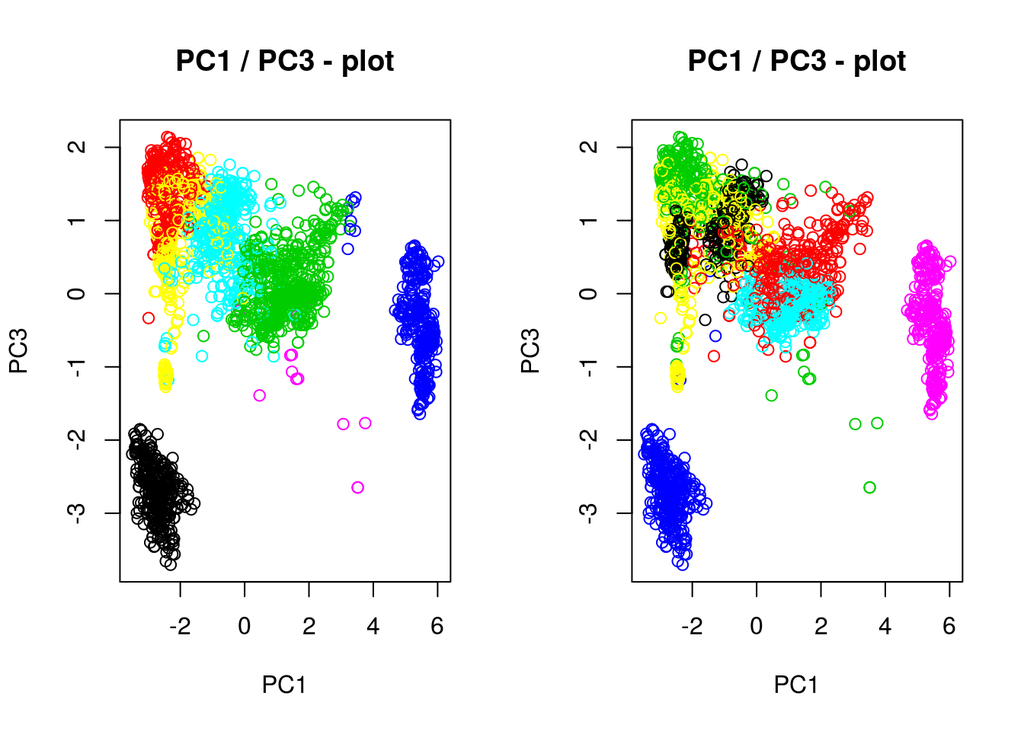

```r
clusters <- kmeans(df, n_class)
pca_df <- prcomp(df)
par(mfrow=c(1,2))
plot(pca_df$x[,1], pca_df$x[,3], xlab="PC1", ylab = "PC3", main = "PC1 / PC3 - plot", col = clusters$cluster)
plot(pca_df$x[,1], pca_df$x[,3], xlab="PC1", ylab = "PC3", main = "PC1 / PC3 - plot", col = labels)
```

#### 1.4.2.2 k-medoids

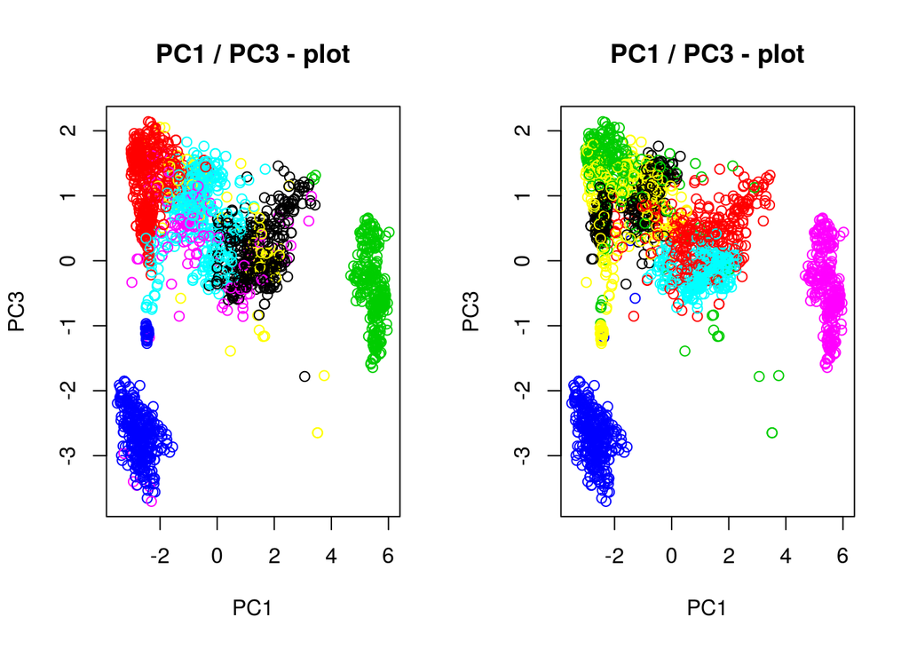

```r
clusters <- pam(df, n_class)
pca_df <- prcomp(df)
par(mfrow=c(1,2))
plot(pca_df$x[,1], pca_df$x[,3], xlab="PC1", ylab = "PC3", main = "PC1 / PC3 - plot", col = clusters$cluster)
plot(pca_df$x[,1], pca_df$x[,3], xlab="PC1", ylab = "PC3", main = "PC1 / PC3 - plot", col = labels)
```

### 1.4.3 Analiza wyników

Należy zauważyć całkowicie różne zachowanie przypadku dwóch klastróch. Metodą k-medoidów otrzymujemy dwa klastry rzeczywiście wyróżniające się na wykresie składowych głównych. Natomiast metodą k-średnich otrzymujemy jeden duży klaster oraz drugi jako zbiór obserwacji odstających (wnioskując po wykresie składowych głównych).

W przypadku wybrania siedmiu klastrów (na podstawie informacji o danych oraz metryki `wss`) otrzymujemy trudną do zwizualizowania strukturę podziału, podobną w przypadku obu algorytmów. Na prawo od wykresów klasteryzacji znajdują się wykresy z oryginalnymi etykietami (niestety z rozbieżnością kolorów).

## 1.5 Porównanie centrów klastrów

Poniżej wykresy odpowiednio dla k-means i k-medoids:

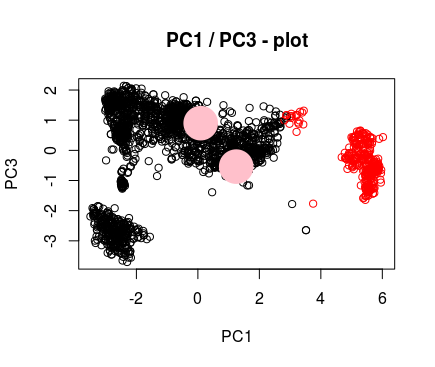

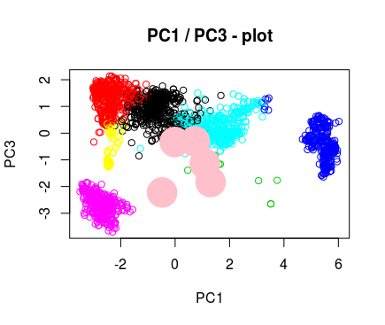

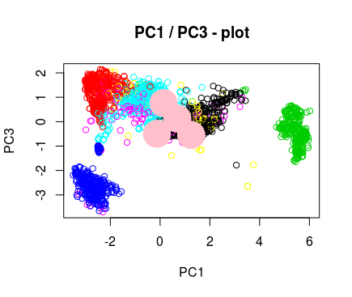

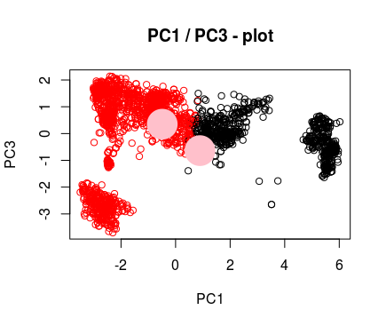

Kmeans:

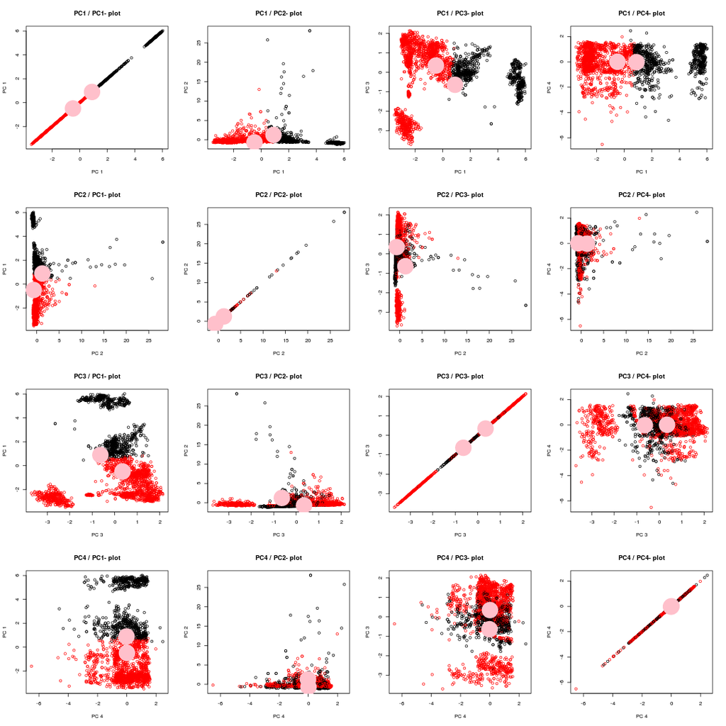

Kmedoids:

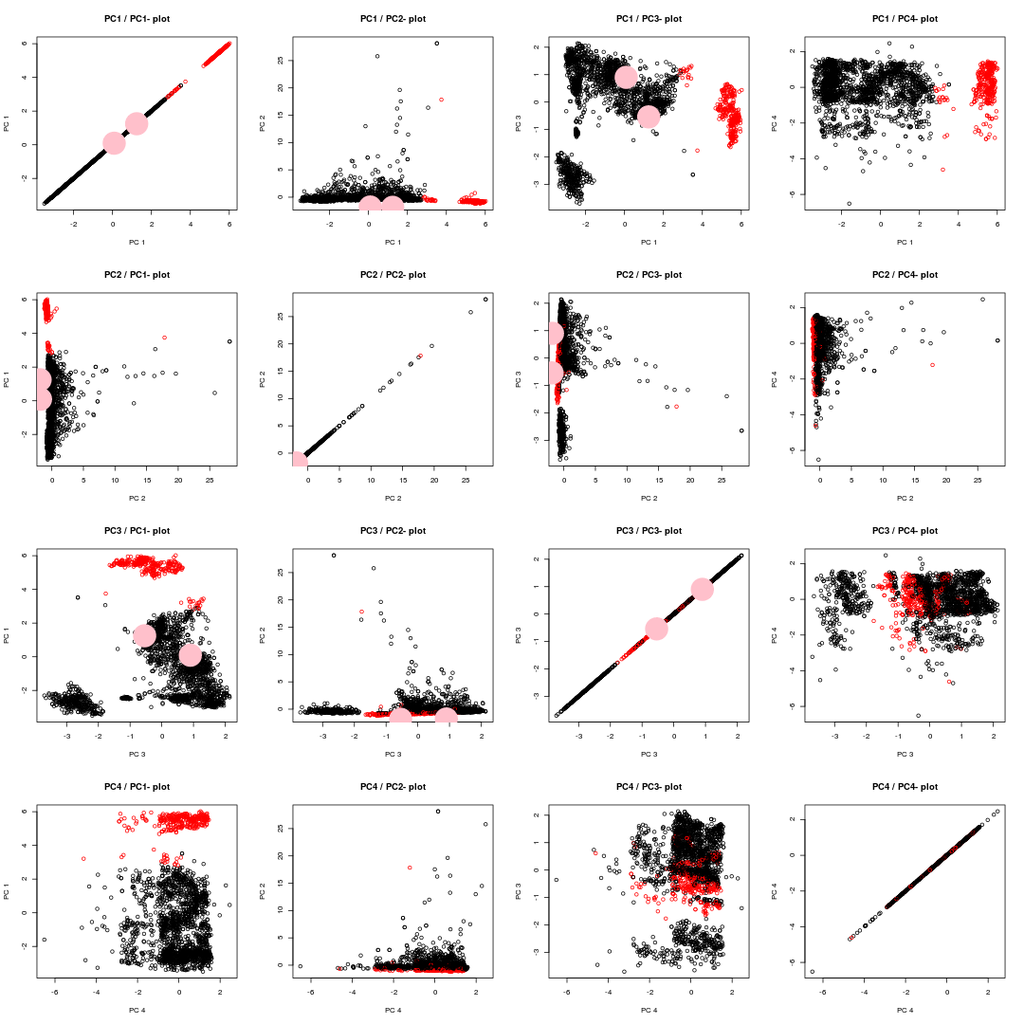

Poniżej wykres k-medoids dla siedmiu klastrów:

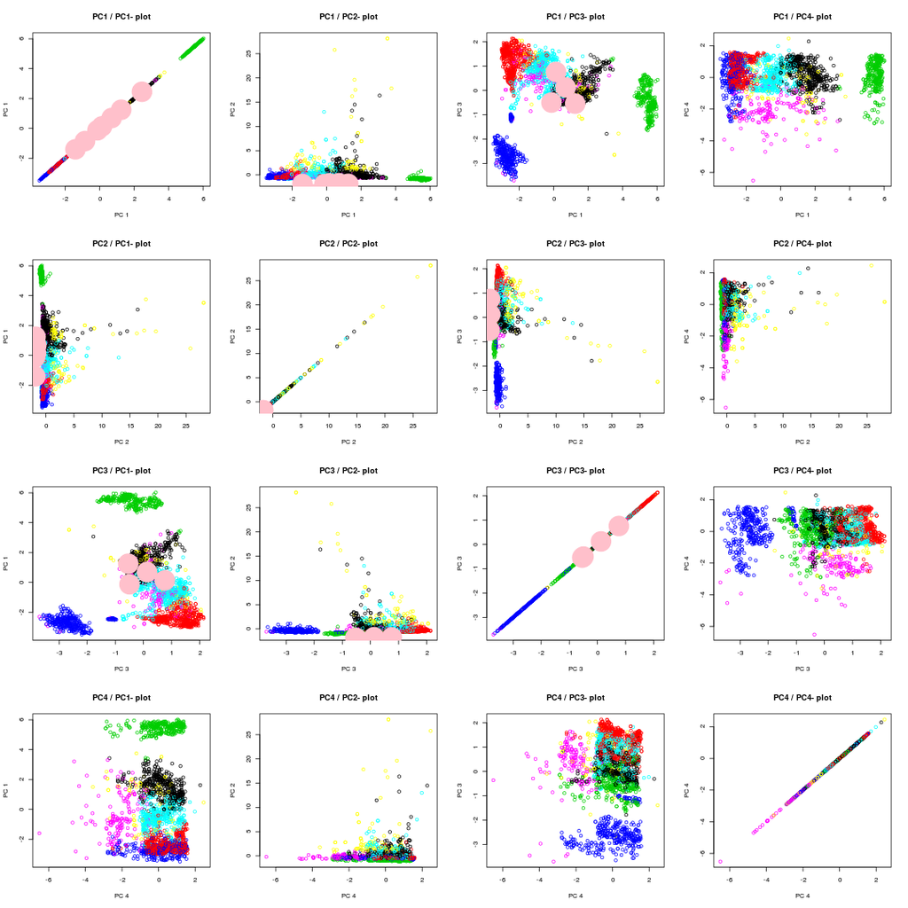

### 1.5.1 Analiza wyników

Trudno dobrze zauważyć dobrze rozmieszczenie centrów klastrów przy użyciu dwóch zmiennych. Zastosowano większe wykresy zależności pomiędzy parami zmiennych wynikowych PCA dla pokazania zależności pomiędzy centrami. Dla wielu z tych wykresów nie widać żadnego rozdzielenia centrów. Nie znaleziono zauważalnej różnicy pomiędzy centrami dla k-means i k-medoids.

## 1.6 Źródła

- [1] Opis zbioru w OpenML; https://www.openml.org/d/36